# Cointegración y el método de corrección de errores

v. 2026.05.26

## Introducción

## Motivación (1/2)

Consideremos el *modelo de demanda de dinero*:

\[ m_t \;=\; \beta_0 \;+\; \underset{=1}{\beta_1} \; p_t + \underset{>0}{\beta_2} \; y_t \;+\; \underset{<0}{\beta_3} \;r_t \;+\; e_t \]

donde:

\[ \begin{align} m_t &: \text{Demanda de dinero} \\ p_t &: \text{Nivel de precios} \\ y_t &: \text{Ingreso real} \\ r_t &: \text{Tasa de interés real} \\ e_t &: \text{Término de error} \\ \end{align} \]

La teoría económica sugiere que la demanda de dinero real, \(m_t\), no debería desviarse permanentemente de su trayectoria. ¡Esto implica que el término de error \(e_t\) debe ser *estacionario*!

## Motivación (2/2)

En el ejemplo anterior, si aplicamos pruebas de raíz unitaria (es decir, un análisis de estacionariedad) a \(m_t\), \(p_t\), \(y_t\) y \(r_t\), lo más probable es que todas sean \(I(1)\). Entonces:

\[ e_t \;=\; m_t - \beta_0 - \beta_1 p_t - \beta_2 y_t + \beta_3 r_t \]

Es decir, el término de error \(e_t\), que es estacionario, resulta de una combinación lineal de variables no estacionarias.

## Cointegración

## Equilibrio de largo plazo

Del ejemplo anterior podemos deducir la definición de **cointegración**.

Primero, diremos que un conjunto de variables económicas se encuentra en *equilibrio de largo plazo* cuando existe una combinación lineal de estas tal que:

\[ \begin{align} \beta_1 x_1 + \beta_2 x_2 + \dots + \beta_k x_k &= \mathbf{x}\boldsymbol{\beta}\\ \;&=\; 0 , \end{align} \]

## Error de equilibrio

Aunque idealmente \(\mathbf{x}\boldsymbol{\beta} = 0\), en la práctica puede ocurrir que:

\[ \mathbf{x}\boldsymbol{\beta} = e_t \]

El término \(e_t\) es el **error de equilibrio**. Este puede reflejar *desviaciones transitorias* del punto de equilibrio. Si este es el caso y \(e_t\sim I(0)\), decimos que las variables del vector \(\mathbf x\) tienen una relación *estadística* de largo plazo.

## Cointegración (1/2)

Las variables del vector \(\mathbf x\) están *cointegradas de orden \((d,b)\)* si:

1. Todos sus componentes están integradas de orden \(d\), \(x_i \sim I(d)\);
2. Existe un vector \(\boldsymbol{\beta}\) tal que la combinación lineal \(\mathbf{x}\boldsymbol{\beta} \sim I(d-b)\) con \(b>0\).

El vector \(\boldsymbol{\beta}\) se denomina **vector de cointegración**.

## Cointegración (2/2)

Nota

- Si \(\mathbf x\) tiene \(k\) componentes no estacionarios, pueden existir hasta \(h<k\) vectores de cointegración linealmente independientes.
- El número \(h\) se conoce como **rango de cointegración**.

## Ejemplos (1/2)

En nuestro ejemplo de demanda de dinero, un vector de cointegración es:

\[ \boldsymbol{\beta}_1 = \begin{pmatrix} 1 & -\beta_0 & -\beta_1 & -\beta_2 & -\beta_3 \end{pmatrix} \]

Sin embargo, supongamos que existe una regla de política económica (monetaria) tal que:

\[ \begin{align} \uparrow m_t \; & \rightarrow \; \downarrow (p_t + y_t) \\ \downarrow m_t \; & \rightarrow \; \uparrow (p_t + y_t) \\ \end{align} \]

En este caso, tenemos un segundo vector de cointegración:

\[ \boldsymbol{\beta}_2= \begin{pmatrix} 1 & -\gamma_0 & \gamma_1 & \gamma_2 & 0 \end{pmatrix} \]

## Ejemplos (2/2)

Ejercicio

Considera el siguiente modelo:

\[ \begin{align} y_{1,t} &= \gamma y_{2,t} + u_{1t} \\ y_{2,t} &= y_{2,t-1} + u_{2t} \\ u_{it} & \sim WN(0,\sigma^2_i); \ i=1,2\\ \mathbb{C}ov(u_{it},u_{it-h}) &= 0 \\ \mathbb{C}ov(u_{it},u_{jt}) &= 0 \end{align} \]

Muestra que \(y_{1,t}\) y \(y_{2,t}\) están cointegradas. ¿Cuál es el vector de cointegración, \(\boldsymbol{\beta}\)?

## Modelo de corrección de errores (ECM)

## Modelo de corrección de errores (1/3)

Considera un *modelo de la estructura temporal de las tasas de interés*:

\[ \begin{aligned} \Delta r_{s,t} &= \alpha_s\bigl(r_{s,t-1} - \beta\,r_{l,t-1}\bigr) + \sum_{i=1}^{p}\gamma_{si}\,\Delta r_{s,t-i} + \sum_{i=1}^{p}\delta_{si}\,\Delta r_{l,t-i} + u_{s,t},\\[6pt] \Delta r_{l,t} &= \alpha_l\bigl(r_{s,t-1} - \beta\,r_{l,t-1}\bigr) + \sum_{i=1}^{p}\gamma_{li}\,\Delta r_{s,t-i} + \sum_{i=1}^{p}\delta_{li}\,\Delta r_{l,t-i} + u_{l,t}. \end{aligned} \]

Si las tasas son \(I(1)\) y los términos de error son ruidos blancos (posiblemente correlacionados), los términos entre paréntesis deben ser estacionarios. Estos términos representan el error de equilibrio.

## Modelo de corrección de errores (2/3)

El modelo anterior nos permite analizar cómo se corrigen los *desequilibrios de corto plazo* en las tasas de interés. Este es un ejemplo de **modelo de corrección de errores (ECM)**.

Nota

Para que el modelo de corrección de errores exista, es necesario que las variables \(r_{s,t}\) y \(r_{l,t}\) estén cointegradas. En el ejemplo estas están cointegradas de orden \((1,1)\) y el vector de cointegración es \(\begin{pmatrix} 1 & -\beta\end{pmatrix}\).

## Modelo de corrección de errores (3/3)

Nota que no existe corrección de errores si:

- las variables no están cointegradas, o
- \(\alpha_s = \alpha_l = 0\).

En tal caso, el modelo se reduce a un VAR para las primeras diferencias de \(r_{s,t}\) y \(r_{l,t}\). Esto es, un VAR para \(\Delta r_{s,t}\) y \(\Delta r_{l,t}\).

## Procedimiento de Engle–Granger

## Procedimiento de Engle–Granger

Consideremos dos variables, \(y_t\) y \(z_t\), posiblemente \(I(1)\). El procedimiento de Engle y Granger consta de cuatro pasos.

## Paso 1

Confirmar el orden de integración de \(y_t\) y \(z_t\):

- Si las dos variables son efectivamente \(I(1)\) continuamos al paso 2.
- Si las dos variables están integradas de diferente orden, podemos concluir que no están cointegradas.
- Si las dos variables son \(I(0)\) (estacionarias) ajustamos a cada una de ellas un modelo del tipo ARMA.

## Paso 2

Estimar la relación de largo plazo entre \(y_t\) y \(z_t\):

\[ y_t = \beta_0 + \beta_1 z_t + u_t. \]

Para que exista cointegración, es necesario que el término \(u_t\) sea estacionario. Para esto, y dado que \(u_t\) es desconocido, aplicamos una prueba de Dickey-Fuller (aumentada) al término:

\[ e_t = y_t - \hat{y}_t \]

*Nota*. En la prueba de DF, usamos las **tablas de Engle-Granger** en lugar de las de DF.

## Paso 3

Si \(y_t\) y \(z_t\) están cointegradas, el ECM (como un VAR restringido):

\[ \begin{align} \Delta y_t &= \alpha_1 + \alpha_y\,\left(y_{t-1} - \beta_0 - \beta_1 z_{t-1}\right) + \sum_{i=1}^{p}a_{1,1}(i)\,\Delta y_{t-i} + \sum_{i=1}^{p}a_{1,2}(i)\,\Delta z_{t-i} + \varepsilon_{y,t}\\ \Delta z_t &= \alpha_2 + \alpha_z\,\left(y_{t-1} - \beta_0 - \beta_1 z_{t-1}\right) + \sum_{i=1}^{p}a_{2,1}(i)\,\Delta y_{t-i} + \sum_{i=1}^{p}a_{2,2}(i)\,\Delta z_{t-i} + \varepsilon_{z,t}\\ \end{align} \]

Engle–Granger sugieren sustituir \(y_{t-1} - \beta_0 - \beta_1 z_{t-1}\) por \(\hat e_{t-1}\) obtenido en el paso 2.

## Paso 4

Revisamos si el modelo es adecuado:

- Revisamos si los residuales del modelo son ruidos blancos.
- Revisamos la estimación de las velocidades de ajuste. Si estos son estadísticamente iguales a cero, concluimos que no existe un ECM.
- Si el ECM es válido, podemos calcular las funciones de impulso-respuesta y descomposición de la varianza para analizar el comportamiento del modelo.

## Ejemplo (1/9)

Consideremos al Producto Interno Bruto de Estados Unidos (USA) y de Australia (AUS).

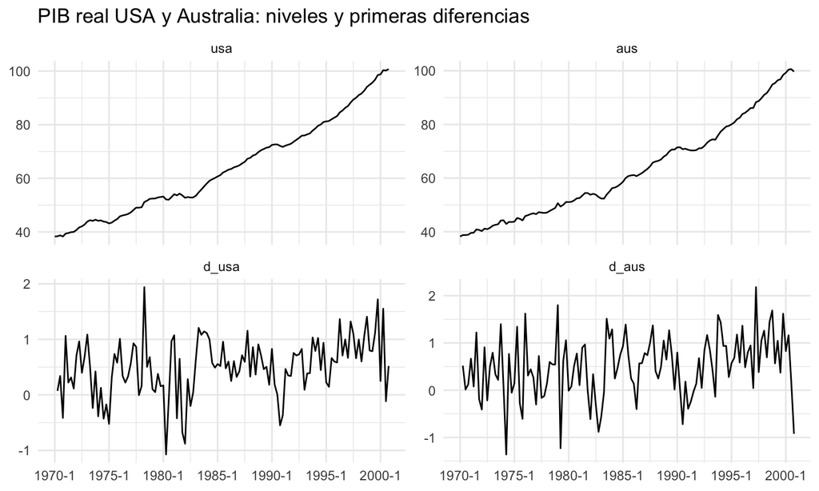

## Ejemplo (2/9)

```
##
## ###############################################################
## # Augmented Dickey-Fuller Test Unit Root / Cointegration Test #
## ###############################################################
##
## The value of the test statistic is: -8.0085 32.0712
```

```
##       1pct  5pct 10pct
## tau2 -3.46 -2.88 -2.57
## phi1  6.52  4.63  3.81
```

## Ejemplo (3/9)

```
##
## ###############################################################
## # Augmented Dickey-Fuller Test Unit Root / Cointegration Test #
## ###############################################################
##
## The value of the test statistic is: -9.4353 44.5326
```

```
##       1pct  5pct 10pct
## tau2 -3.46 -2.88 -2.57
## phi1  6.52  4.63  3.81
```

## Ejemplo (4/9)

El segundo paso del procedimiento de Engle-Granger comienza estimando la relación de largo plazo entre las series USA y AUS. Aquí estimamos la siguiente relación:

\[ aus_t = \beta_0 + \beta_1 usa_t + u_t \]

```
##
## Call:
## lm(formula = aus ~ usa, data = usaus)
##
## Residuals:
##      Min       1Q   Median       3Q      Max
## -2.47448 -0.92582 -0.08206  1.01575  2.65821
##
## Coefficients:
##             Estimate Std. Error t value Pr(>|t|)
## (Intercept)  -1.0724     0.4032  -2.659  0.00888 **
## usa           1.0010     0.0061 164.090  < 2e-16 ***
## ---
## Signif. codes:  0 '***' 0.001 '**' 0.01 '*' 0.05 '.' 0.1 ' ' 1
##
## Residual standard error: 1.19 on 122 degrees of freedom
## Multiple R-squared:  0.9955, Adjusted R-squared:  0.9955
## F-statistic: 2.693e+04 on 1 and 122 DF,  p-value: < 2.2e-16
```

## Ejemplo (5/9)

En el Paso 2 del procedimiento de Engle-Granger, tenemos que recuperar el residual de la relación entre las series USA y AUS.

\[ e_t = aus_t - b_0 - b_1 usa_t \]

donde \(b_0\) y \(b_1\) son los estimadores de MCO. Para que las series USA y AUS estén cointegradas, es necesario que este residual se comporte como un ruido blanco (esto es, una serie estacionaria: \(e_t\sim I(0)\)).

## Ejemplo (6/9)

Graficamos el término de corrección de errores, \(e_t\). ¿Parece un ruido blanco?

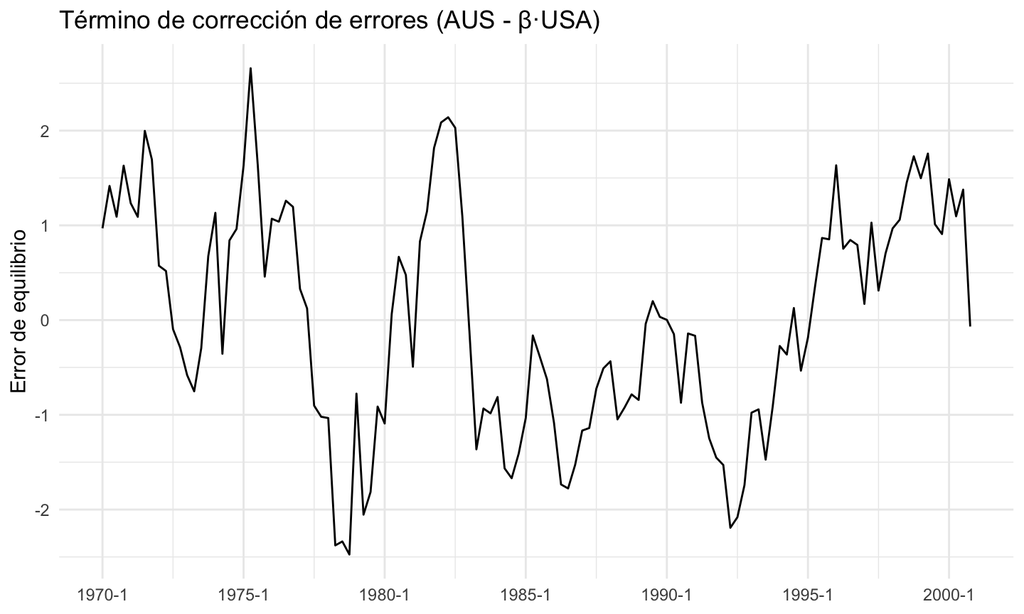

## Ejemplo (7/9)

Una prueba de Dickey-Fuller aumentada aplicada a \(e_t\), indica que este es, de hecho, estacionario:

```
##
## ###############################################################
## # Augmented Dickey-Fuller Test Unit Root / Cointegration Test #
## ###############################################################
##
## The value of the test statistic is: -3.0511
```

```
##       1pct  5pct 10pct
## tau1 -2.58 -1.95 -1.62
```

## Ejemplo (8/9)

Finalmente, dado que las series USA y AUS parecen estar cointegradas, estimamos el modelo de corrección de errores. Este es el Paso 3 del procecimiento de Engle-Granger. Para la serie AUS tenemos:

```
##
## Call:
## lm(formula = d_aus ~ 1 + ehat_l1, data = usaus_ecm)
##
## Residuals:
##     Min      1Q  Median      3Q     Max
## -1.8348 -0.4084  0.0011  0.3905  1.7042
##
## Coefficients:
##             Estimate Std. Error t value Pr(>|t|)
## (Intercept)  0.49963    0.05688   8.784 1.25e-14 ***
## ehat_l1     -0.13862    0.04798  -2.889  0.00458 **
## ---
## Signif. codes:  0 '***' 0.001 '**' 0.01 '*' 0.05 '.' 0.1 ' ' 1
##
## Residual standard error: 0.6308 on 121 degrees of freedom
## Multiple R-squared:  0.06453,    Adjusted R-squared:  0.0568
## F-statistic: 8.347 on 1 and 121 DF,  p-value: 0.004578
```

## Ejemplo (9/9)

El modelo de corrección de errores para USA es:

```
##
## Call:
## lm(formula = d_usa ~ 1 + ehat_l1, data = usaus_ecm)
##
## Residuals:
##      Min       1Q   Median       3Q      Max
## -1.58073 -0.28634  0.01296  0.33653  1.43244
##
## Coefficients:
##              Estimate Std. Error t value Pr(>|t|)
## (Intercept) 0.5074786  0.0466973   10.87   <2e-16 ***
## ehat_l1     0.0004075  0.0393911    0.01    0.992
## ---
## Signif. codes:  0 '***' 0.001 '**' 0.01 '*' 0.05 '.' 0.1 ' ' 1
##
## Residual standard error: 0.5179 on 121 degrees of freedom
## Multiple R-squared:  8.845e-07,  Adjusted R-squared:  -0.008264
## F-statistic: 0.000107 on 1 and 121 DF,  p-value: 0.9918
```

## Modelo de corrección de errores vectorial (VECM)

## Modelo de corrección de errores vectorial (VECM)

El modelo de corrección de errores permite describir el ajuste de *una variable* ante desviaciones del equilibrio de largo plazo. Sin embargo, este enfoque tiene dos limitaciones importantes:

1. Solo permite un vector de cointegración.
2. Modela el ajuste ecuación por ecuación, no como un sistema.

En contextos multivariados, especialmente cuando varias variables interactúan simultáneamente, es natural permitir que *todas* respondan a los desequilibrios de largo plazo. El modelo que permite hacerlo es el **Modelo de Corrección de Errores Vectorial (VECM)**.

## Del VAR al VECM

Consideremos un modelo VAR(\(p\)) para un vector \(k\times 1\) de variables \(y_t\):

\[ y_t = A_1 y_{t-1} + A_2 y_{t-2} + \dots + A_p y_{t-p} + u_t, \quad u_t \sim WN(0,\Sigma). \]

Restando \(y_{t-1}\) de ambos lados y reordenando términos, obtenemos:

\[ \Delta y_t = \Pi\, y_{t-1} + \Gamma_1 \Delta y_{t-1} + \Gamma_2 \Delta y_{t-2} + \dots + \Gamma_{p-1} \Delta y_{t-p+1} + u_t, \]

donde:

\[ \Pi = -(I - A_1 - A_2 - \dots - A_p), \]

y las matrices \(\Gamma_i\) recogen la dinámica de corto plazo.

## Cointegración y la matriz \(\Pi\) (1/2)

La relación anterior se conoce como la **forma VECM del VAR**. La matriz \(\Pi\) contiene toda la información relevante sobre el *largo plazo* del sistema. Dependiendo de su rango, pueden darse tres casos:

- Si \(\text{rank}(\Pi) = 0\), no existe cointegración y el modelo se reduce a un VAR en primeras diferencias.
- Si \(\text{rank}(\Pi) = k\), todas las variables son estacionarias en niveles.
- Si \(0 < \text{rank}(\Pi) = r < k\), existen \(r\) **relaciones de cointegración**.

## Cointegración y la matriz \(\Pi\) (2/2)

Cuando existen \(r\) relaciones de cointegración, la matriz \(\Pi\) puede factorizarse como:

\[ \Pi = \alpha \beta', \]

donde: \(\beta\) es una matriz \(k \times r\) cuyos vectores columna son los *vectores de cointegración*, y \(\alpha\) es una matriz \(k \times r\) que contiene las *velocidades de ajuste* de cada variable ante desviaciones del equilibrio.

## Interpretación del VECM

Cada ecuación del VECM contiene dos componentes fundamentales:

1. **Dinámica de corto plazo**, capturada por las primeras diferencias y las matrices \(\Gamma_i\).
2. **Corrección de errores**, capturada por el término \(\alpha\beta' y_{t-1}\), que mide cómo las variables reaccionan ante desequilibrios de largo plazo.

Aunque todas las ecuaciones comparten las mismas relaciones de equilibrio \(\beta\), cada variable puede ajustarse de manera distinta, dependiendo de los coeficientes de \(\alpha\).

## Relación entre ECM y VECM

Nota

El modelo de corrección de errores univariado (ECM) es un caso particular del VECM.

- Cuando \(k=2\) y \(r=1\), el VECM se reduce a un sistema con un solo término de corrección de errores.
- Al estimar una sola ecuación de ese sistema, se obtiene el ECM de Engle–Granger.

En este sentido, el VECM generaliza el enfoque de Engle–Granger a sistemas multivariados.

## Estimación del VECM: método de Johansen

El VECM se estima habitualmente mediante el **método de Johansen**, el cual:

- se basa en máxima verosimilitud,
- permite determinar el rango de cointegración \(r\),
- estima simultáneamente las matrices \(\alpha\) y \(\beta\),
- es válido para sistemas con más de dos variables.

El método utiliza dos pruebas estadísticas para determinar \(r\):

- la **prueba de la traza** (*trace test*), y
- la **prueba del máximo eigenvalor** (*maximum eigenvalue test*).

Ambas contrastan la hipótesis nula de que el número de vectores de cointegración es menor o igual a un valor dado.

## Ejemplo VECM (1/5)

Consideremos nuevamente el ejemplo del PIB real de Estados Unidos y Australia.

Dado que ambas series parecen ser \(I(1)\) y el procedimiento de Engle–Granger sugiere cointegración, podemos estimar un VECM mediante el método de Johansen.

## Ejemplo VECM (2/5)

La prueba de la traza permite determinar el número de relaciones de cointegración.

```
##
## ######################
## # Johansen-Procedure #
## ######################
##
## Test type: trace statistic , without linear trend and constant in cointegration
##
## Eigenvalues (lambda):
## [1] 2.614149e-01 7.108068e-02 4.440892e-16
##
## Values of teststatistic and critical values of test:
##
##           test 10pct  5pct  1pct
## r <= 1 |  9.00  7.52  9.24 12.97
## r = 0  | 45.96 17.85 19.96 24.60
##
## Eigenvectors, normalised to first column:
## (These are the cointegration relations)
##
##              usa.l2     aus.l2  constant
## usa.l2    1.0000000  1.0000000  1.000000
## aus.l2   -0.8151535 -0.9897382 -1.610538
## constant -2.9079884 -1.8150309 39.642121
##
## Weights W:
## (This is the loading matrix)
##
##           usa.l2      aus.l2      constant
## usa.d 0.03925578 -0.05228363 -8.065548e-17
## aus.d 0.04252620  0.08997669  3.382537e-16
```

La hipótesis nula es:

\[ H_0: r \leq r_0, \] donde \(r\) representa el rango de cointegración.

## Ejemplo VECM (3/5)

```
## Response usa.d :
##
## Call:
## lm(formula = usa.d ~ ect1 + usa.dl1 + aus.dl1 - 1, data = data.mat)
##
## Residuals:
##      Min       1Q   Median       3Q      Max
## -1.44688 -0.25550  0.00058  0.35454  1.59321
##
## Coefficients:
##         Estimate Std. Error t value Pr(>|t|)
## ect1    0.039256   0.006865   5.719 8.13e-08 ***
## usa.dl1 0.241588   0.096944   2.492   0.0141 *
## aus.dl1 0.006636   0.080499   0.082   0.9344
## ---
## Signif. codes:  0 '***' 0.001 '**' 0.01 '*' 0.05 '.' 0.1 ' ' 1
##
## Residual standard error: 0.4855 on 119 degrees of freedom
## Multiple R-squared:  0.5625, Adjusted R-squared:  0.5515
## F-statistic: 51.01 on 3 and 119 DF,  p-value: < 2.2e-16
##
##
## Response aus.d :
##
## Call:
## lm(formula = aus.d ~ ect1 + usa.dl1 + aus.dl1 - 1, data = data.mat)
##
## Residuals:
##      Min       1Q   Median       3Q      Max
## -1.53604 -0.39022 -0.04166  0.40008  1.42633
##
## Coefficients:
##         Estimate Std. Error t value Pr(>|t|)
## ect1     0.04253    0.00861   4.939 2.59e-06 ***
## usa.dl1  0.29423    0.12160   2.420    0.017 *
## aus.dl1 -0.08467    0.10097  -0.839    0.403
## ---
## Signif. codes:  0 '***' 0.001 '**' 0.01 '*' 0.05 '.' 0.1 ' ' 1
##
## Residual standard error: 0.609 on 119 degrees of freedom
## Multiple R-squared:  0.4611, Adjusted R-squared:  0.4475
## F-statistic: 33.93 on 3 and 119 DF,  p-value: 6.386e-16
```

Los coeficientes asociados al término de corrección de errores representan las velocidades de ajuste de cada variable ante desviaciones del equilibrio de largo plazo.

## Ejemplo VECM (4/5)

Interpretación:

- El VECM incorpora simultáneamente: 1) la dinámica de corto plazo, y 2) el equilibrio de largo plazo.
- El término de corrección de errores indica cómo reaccionan USA y AUS ante desviaciones del equilibrio.
- Una vez estimado el VECM, es posible calcular funciones de impulso–respuesta, descomposición de la varianza, etc.